# Palmer Penguins Modeling

Import the Palmer Penguins dataset and print out the first few rows.

Suppose we want to predict `bill_depth_mm` using the other variables in the dataset.

Which variables would we need to **dummify**?

```python
# Set-up
!pip install pandas
!pip install palmerpenguins

import pandas as pd
from palmerpenguins import load_penguins

penguins = load_penguins()
```

```python
# Run penguins to see what our variables are.
penguins
```

|  | species | island | bill_length_mm | bill_depth_mm | flipper_length_mm | body_mass_g | sex | year |
| --- | --- | --- | --- | --- | --- | --- | --- | --- |
| 0 | Adelie | Torgersen | 39.1 | 18.7 | 181.0 | 3750.0 | male | 2007 |
| 1 | Adelie | Torgersen | 39.5 | 17.4 | 186.0 | 3800.0 | female | 2007 |
| 2 | Adelie | Torgersen | 40.3 | 18.0 | 195.0 | 3250.0 | female | 2007 |
| 3 | Adelie | Torgersen | NaN | NaN | NaN | NaN | NaN | 2007 |
| 4 | Adelie | Torgersen | 36.7 | 19.3 | 193.0 | 3450.0 | female | 2007 |
| ... | ... | ... | ... | ... | ... | ... | ... | ... |
| 339 | Chinstrap | Dream | 55.8 | 19.8 | 207.0 | 4000.0 | male | 2009 |
| 340 | Chinstrap | Dream | 43.5 | 18.1 | 202.0 | 3400.0 | female | 2009 |
| 341 | Chinstrap | Dream | 49.6 | 18.2 | 193.0 | 3775.0 | male | 2009 |
| 342 | Chinstrap | Dream | 50.8 | 19.0 | 210.0 | 4100.0 | male | 2009 |
| 343 | Chinstrap | Dream | 50.2 | 18.7 | 198.0 | 3775.0 | female | 2009 |

344 rows × 8 columns

```python
# We would need to dummify the variables "species", "island", and "sex" since those are the non-numerical variables.

dum_penguins = pd.get_dummies(penguins, columns=['species', 'island', 'sex'], drop_first=True)

dum_penguins
```

|  | bill_length_mm | bill_depth_mm | flipper_length_mm | body_mass_g | year | species_Chinstrap | species_Gentoo | island_Dream | island_Torgersen | sex_male |
| --- | --- | --- | --- | --- | --- | --- | --- | --- | --- | --- |
| 0 | 39.1 | 18.7 | 181.0 | 3750.0 | 2007 | 0 | 0 | 0 | 1 | 1 |
| 1 | 39.5 | 17.4 | 186.0 | 3800.0 | 2007 | 0 | 0 | 0 | 1 | 0 |
| 2 | 40.3 | 18.0 | 195.0 | 3250.0 | 2007 | 0 | 0 | 0 | 1 | 0 |
| 3 | NaN | NaN | NaN | NaN | 2007 | 0 | 0 | 0 | 1 | 0 |
| 4 | 36.7 | 19.3 | 193.0 | 3450.0 | 2007 | 0 | 0 | 0 | 1 | 0 |
| ... | ... | ... | ... | ... | ... | ... | ... | ... | ... | ... |
| 339 | 55.8 | 19.8 | 207.0 | 4000.0 | 2009 | 1 | 0 | 1 | 0 | 1 |
| 340 | 43.5 | 18.1 | 202.0 | 3400.0 | 2009 | 1 | 0 | 1 | 0 | 0 |
| 341 | 49.6 | 18.2 | 193.0 | 3775.0 | 2009 | 1 | 0 | 1 | 0 | 1 |
| 342 | 50.8 | 19.0 | 210.0 | 4100.0 | 2009 | 1 | 0 | 1 | 0 | 1 |
| 343 | 50.2 | 18.7 | 198.0 | 3775.0 | 2009 | 1 | 0 | 1 | 0 | 0 |

344 rows × 10 columns

Let's use `bill_length_mm` to predict `bill_depth_mm`. Prepare your data and fit the following models on the entire dataset:

- Simple linear regression (e.g. straight-line) model
- Quadratic (degree 2 polynomial) model
- Cubic (degree 3 polynomial) model
- Degree 10 polynomial model

Make predictions for each model and plot your fitted models on the scatterplot.

```python
# Import relevant libraries
import sklearn
import pandas as pd
import numpy as np

from sklearn.linear_model import LinearRegression
lr = LinearRegression()
```

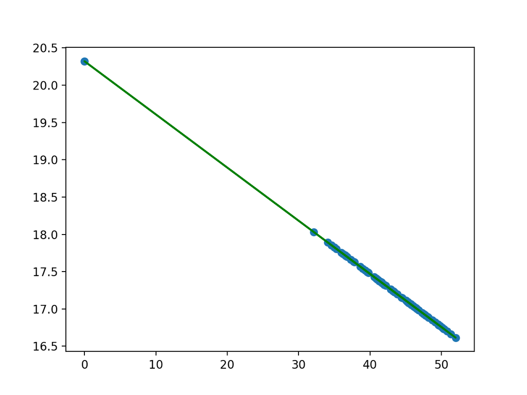

```python
# Define predictor and response variables
y = dum_penguins['bill_depth_mm'].fillna(0)
X = dum_penguins[['bill_length_mm']].fillna(0)

# Split training and testing data
from sklearn.model_selection import train_test_split
X_train, X_test, y_train, y_test = train_test_split(X, y, test_size=0.25)

# Creating simple lr model
lr_fit = lr.fit(X_train, y_train)
lr_fit.coef_
y_pred_lr = lr_fit.predict(X_test)
y_pred_lr
final_model = lr.fit(X, y)

# Plotting simple lr model
import matplotlib.pyplot as plt
plt.scatter(X_test, y_pred_lr)
plt.plot(X_test, y_pred_lr, color='green')
```

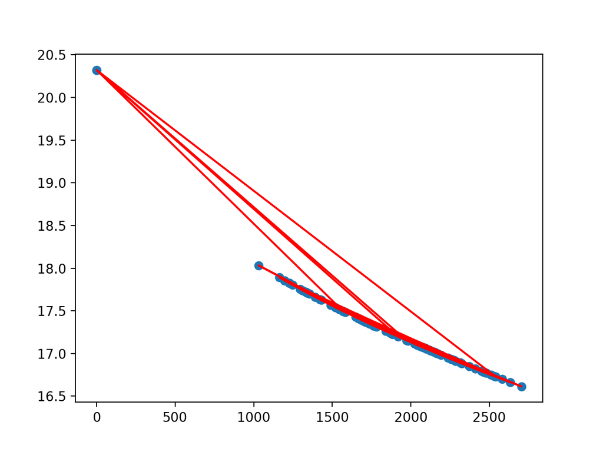

```python
# Plotting deg-2 model
plt.scatter((X_test)**2, y_pred_lr)
plt.plot((X_test)**2, y_pred_lr, color='red')
```

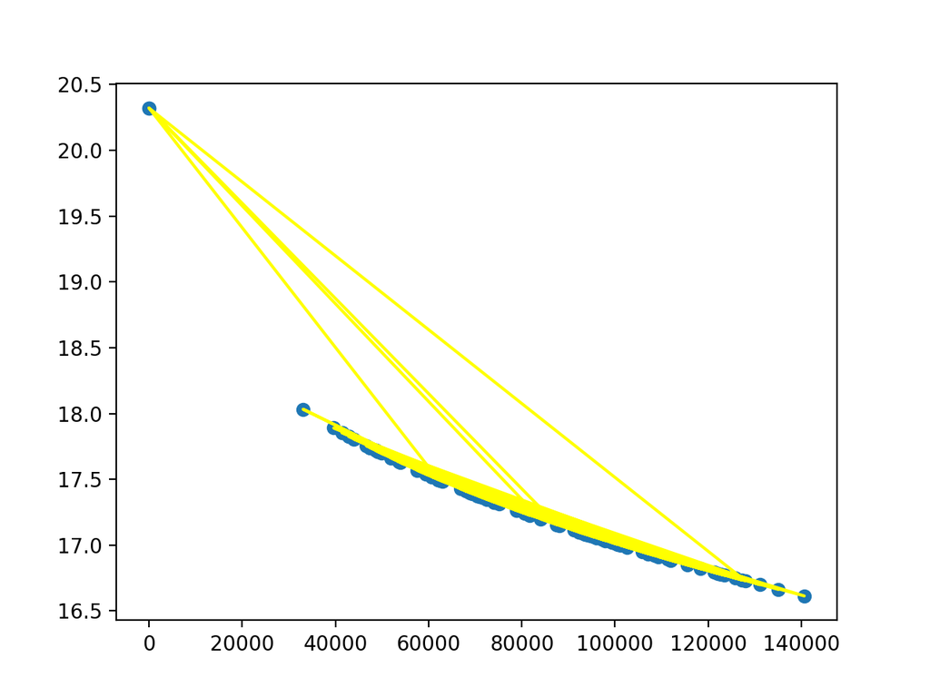

```python
# Plotting deg-3 model
plt.scatter((X_test)**3, y_pred_lr)
plt.plot((X_test)**3, y_pred_lr, color='yellow')
```

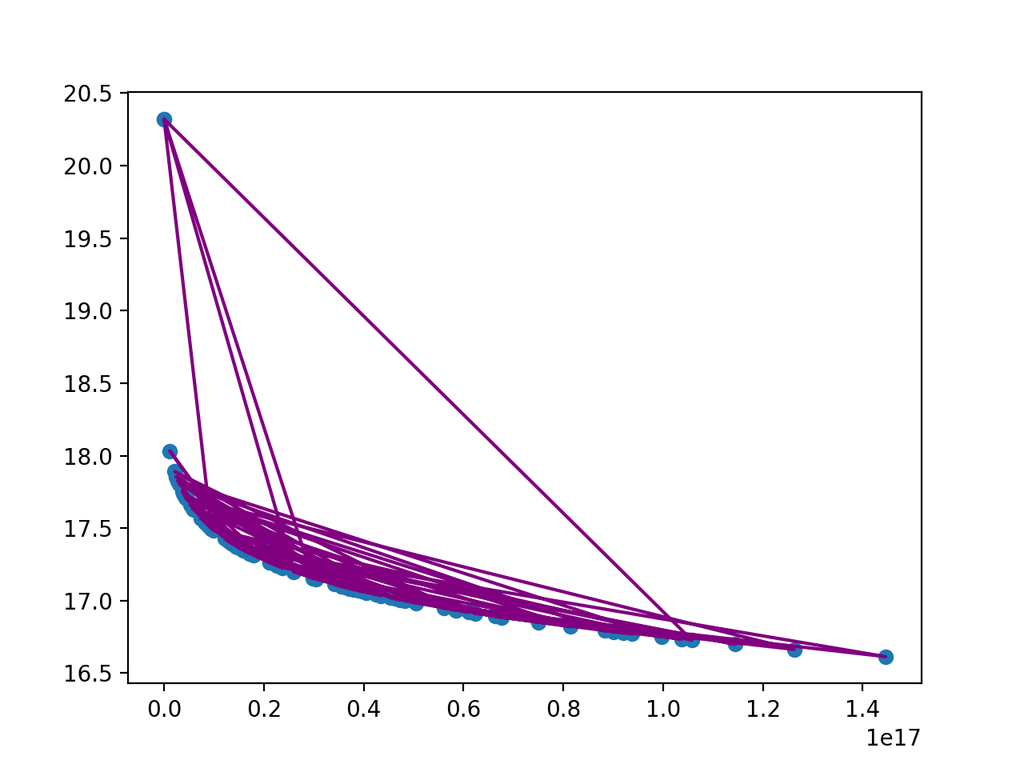

```python
# Plotting deg-10 model
plt.scatter((X_test)**10, y_pred_lr)
plt.plot((X_test)**10, y_pred_lr, color='purple')
```

- Are any of the models above underfitting the data? If so, which ones and how can you tell?
- Are any of thhe models above overfitting the data? If so, which ones and how can you tell?
- Which of the above models do you think fits the data best and why?

**The simple regression model appears to underfit as it makes it seem that the relationship between the two variables is perfectly linear which is not likely or realistic.**